# Case_Study_4_Code

Brian Gaither, Sean Mcwhirter, Andrew Mejia, Sabrina Purvis

2021-01-29 09:43:44

```r
library(tidyverse)
library(hms)
library(rvest)
library(lubridate)
library(foreach)
library(stringr)
library(iterators)
library(progress)
library(doParallel)
library(doSNOW)
library(dplyr)
library(states)
```

```r
library(ggplot2)
library(ggthemes)
library(SiZer)
```

```r
years = c(1999:2012)
division = 'Overall+Women'
section = '10M'
sex = 'W'
```

#### Functions

#The gen_Link function will generates the link with the query parameters for the searchable database

```r
gen_Link = function(year,division,section,page=1,sex){

  paste0( 'http://www.cballtimeresults.org/performances'
          ,'?division=',division,'&page=',page,
          '&section=',section, '&sex=',sex,
          '&utf8=%E2%9C%93','&year=',year)
          #,'?utf8=%E2%9C%93&section=',section
          #,'&year=',year,'&division=',division,'&page=', page)

}
```

# The gen_Table function will parse through the table of 20 records and 15 observations

# and parse the table into its own data frame from xml2 read)html function and then use

# the pipe operator to use rvest nodes to find the table structure

# then the fucntion will insert the metadata for the query parameters of year, division, section, page, source link and sex

```r
gen_Table = function(year,division,section,page, sex){


  #use gen_link function to get link to page
  genlink=gen_Link(year,division,section,page=page, sex=sex)

  #read the page, and grab to 'table' tag
  single_table = xml2::read_html(genlink) %>%
    rvest::html_nodes("table")  %>%
    rvest::html_table(fill=TRUE)

  #get the table and add metadata for the query parameters
  table_out = single_table[[1]] %>%
    mutate(year=year, divisionTitle=division, section=section, page=page, source=genlink, sex = sex)

}
```

# This function will use all available cores on machine

# It will process the years in parrell.

# This code has been adapted from

# https://github.com/ngupta23/ds7333_qtw/blob/master/case_study_2/submission_Kannan_Moro_Gupta/code/CS2_ETL.Rmd

# https://cran.r-project.org/web/packages/doSNOW/doSNOW.pdf

# https://stackoverflow.com/questions/36794063/r-foreach-from-single-machine-to-cluster

# https://cran.r-project.org/web/packages/progress/progress.pdf

# https://www.r-bloggers.com/2013/08/the-wonders-of-foreach/

```r
scrapeTables  = function(years,division,section, sex,  max_itr = 500){


library(progress)
library(doParallel)
library(doSNOW)

    #Initialize Parrellel Process to detect number of cores
    #https://cran.r-project.org/web/packages/doSNOW/doSNOW.pdf
    #https://stackoverflow.com/questions/36794063/r-foreach-from-single-machine-to-cluster

    #Generate and register initial clusters based on cores, otherwise, this is a long process
    cl = makeCluster(detectCores())
    doSNOW::registerDoSNOW(cl)

    #Generate progress bar for the parallel loop based on number of years
    #https://cran.r-project.org/web/packages/progress/progress.pdf
    progBar = progress::progress_bar$new(total = length(years),format='[:bar] :percent :eta')
    progress = function(n) progBar$tick()

    #Initialize a parallel loop per each year
    #Intialize tableRaw as empty to loop to be populated as a table dataframe from gen_Table function
    tableRaw=NULL

    #tableRaw will now use for each using years as the iterator to use .combine to rbind
    #.export will do the gen_Table and gen_Link functions simultanlously and
    #options.snow will show the progress bar
    # the %dopar% will process all the years simultaneously.
    #https://www.r-bloggers.com/2013/08/the-wonders-of-foreach/
    tableRaw = foreach(y=years
                      ,.combine=rbind,.export=c('gen_Table','gen_Link')
                      ,.options.snow = list(progress=progress)) %dopar%
      {

        library(foreach)
        library(dplyr)
        #intialize isCompleted variable as FALSE for bool conditions to see if loop has been completed
        isCompleted=FALSE

        #Initiate loop since most pages are 487, we will only loop for the iterations for max_itr
        tableRaw=foreach(p=c(1:max_itr),.combine=rbind) %do%
          if(!isCompleted) {
            message('getting year:',y, ' page:',p,appendLF = F)
            #get the table of the current page
            table = gen_Table(year=y
                             ,division=division
                             ,section=section
                             ,page=p
                             ,sex=sex)
            message(' rows:',nrow(table))
            isCompleted = nrow(table)==0 #if there is record, we are at the last page, no need to read further
            return(table)
          }
        return(tableRaw)
      }
    #Deactivate the cluster of cores
    stopCluster(cl)
    #save the raw data to rda format for later processing based on gender
    saveRDS(tableRaw,file=paste0('CB',sex,'tableRaw.rds'))

  return(tableRaw)
}
```

### The purpose of this function is to transform the raw tables from the scrape

### https://stackoverflow.com/questions/50040968/convert-a-duration-hms-to-seconds

### https://stackoverflow.com/questions/10835908/is-there-a-way-to-convert-mmss-00-to-seconds-00

### https://stackoverflow.com/questions/24173194/remove-parentheses-and-text-within-from-strings-in-r

```r
tableTransform =function(data_df, cols_to_remove=NULL){
  dataDF = data_df %>%
    #Seperate Home town into seperate columns
    separate(col = 'Hometown', c('HomeTown', 'HomeState'), sep = ',', extra = 'merge', remove = TRUE, fill = 'right') %>%
    #Seperate PiS/TiS into seperate columns
    separate(col='PiS/TiS',c('PiS','TiS'),sep='\\/'
             ,extra='drop',remove=TRUE) %>%
    #Seperate PiD/TiD into seperate columns
    separate(col='PiD/TiD',c('PiD','TiD'),sep='\\/'
             ,extra='drop',remove=TRUE) %>%
    #Trim the casted upper HomeTown strings of whitespace
    mutate(HomeTown = toupper(trimws(HomeTown))
           , HomeState = toupper(trimws(HomeState))
           , HomeTown = ifelse(HomeTown %in% c('NR', '', NULL), NA, toupper(trimws(HomeTown)))
           , HomeState = ifelse(HomeState %in% c('NR', '', NULL), NA, toupper(trimws(HomeState)))
           #Check if HomeState is in state.abb or DC and return USA else return the HomeTown as the Country
           , HomeCountry = ifelse(HomeState %in% c(state.abb, "DC"), "USA", HomeTown)
           #Remove White Space
           , PiS = ifelse(trimws(PiS) %in% c('NR', '', NULL), NA, trimws(PiS))
           , TiS = ifelse(trimws(TiS) %in% c('NR', '', NULL), NA, trimws(TiS))
           , PiD = ifelse(trimws(PiD) %in% c('NR', '', NULL), NA, trimws(PiD))
           , TiD = ifelse(trimws(TiD) %in% c('NR', '', NULL), NA, trimws(TiD))
           , Division = ifelse(trimws(Division) %in% c('NR', '', NULL), NA, trimws(Division))
           # Normalize Time to seconds and minutes
           , RawTime = strptime(Time, format='%H:%M:%S')
           , RawTime_S = RawTime$hour * 3600 + RawTime$min * 60 + RawTime$sec
           , RawTime_M = as.numeric(RawTime_S)/60
           , RawPace = strptime(Pace, format = "%M:%OS")
           , RawPace_S = RawPace$min * 60 + RawPace$sec
           #Normalize Age where 'NR' as NA
           , Age = ifelse(Age %in% c("NR"), NA, Age)
           #Cast Variables as appropriate dtypes
           , Age = as.numeric(Age)
           , RawTime_S = as.numeric(RawTime_S)
           , RawPace_S = as.numeric(RawPace_S)
           , RawPace_M = as.numeric(RawPace_S)/60
           , year = as.factor(year)
           #Remove the (<Sex>) from the names
           #, Name = str_replace(Name, " \\s*\\([^\\)]+\\)", '')
           )
  #Remove columns we do not want
  dataDF = dataDF %>% select (-all_of(c(cols_to_remove)))

  return(dataDF %>% select(c( Age, year,  HomeTown, HomeState, HomeCountry, RawTime_S, RawTime_M, RawPace_S, RawPace_M, sex, section, PiS, TiS, PiD, TiD)))
}
```

### Caution takes a long time without hexacore machine

```r
#Women_table = scrapeTables(years=years,division = division,section=section,sex = sex, max_itr = 500)
```

```r
#men_table = scrapeTables(years=years,division = 'Overall+Men',section=section,sex = "M", max_itr = 500)
```

### Load tables from file

```r
mens_table <- readRDS("/media/andrew/Seagate Backup Plus Drive/Documents/School/HomeWork/QTW/DS7333/CASE_STUDY_4/CBMtableRaw.rds")

womens_table <- readRDS("/media/andrew/Seagate Backup Plus Drive/Documents/School/HomeWork/QTW/DS7333/CASE_STUDY_4/CBWtableRaw.rds")
```

### Preview of raw table scrapes

```r
head(womens_table, n = 10)
```

```
##        Race                  Name Age    Time Pace PiS/TiS Division PiD/TiD
## 1  1999 10M        Jane Omoro (W)  26 0:53:37 5:22  1/2358    W2529   1/559
## 2  1999 10M       Jane Ngotho (W)  29 0:53:38 5:22  2/2358    W2529   2/559
## 3  1999 10M Lidiya Grigoryeva (W)  NR 0:53:40 5:22  3/2358       NR      NR
## 4  1999 10M     Eunice Sagero (W)  20 0:53:55 5:24  4/2358    W2024   1/196
## 5  1999 10M   Alla Zhilyayeva (W)  29 0:54:08 5:25  5/2358    W2529   3/559
## 6  1999 10M    Teresa Wanjiku (W)  24 0:54:10 5:25  6/2358    W2024   2/196
## 7  1999 10M     Elana Viazova (W)  38 0:54:29 5:27  7/2358    W3539   1/387
## 8  1999 10M      Gladys Asiba (W)  NR 0:54:50 5:29  8/2358       NR      NR
## 9  1999 10M      Nnenna Lynch (W)  27 0:55:39 5:34  9/2358    W2529   4/559
## 10 1999 10M   Margaret Kagiri (W)  30 0:55:43 5:34 10/2358    W3034   1/529
##       Hometown year divisionTitle section page
## 1        Kenya 1999 Overall+Women     10M    1
## 2        Kenya 1999 Overall+Women     10M    1
## 3       Russia 1999 Overall+Women     10M    1
```

[output cut: 29 more lines]

### Perform the table transformation and remove metadata columns and other columns

```r
cols_for_remove = c("divisionTitle", "source", "Pace", "Time", "RawTime", "RawPace", "page", "Race", "source")
mens_table_T = tableTransform(mens_table, cols_to_remove = all_of(cols_for_remove))
womens_table_T = tableTransform(womens_table, cols_to_remove = all_of(cols_for_remove))
```

### Preview of the transformed table

```r
head(womens_table_T, n = 10)
```

```
##    Age year HomeTown HomeState HomeCountry RawTime_S RawTime_M RawPace_S
## 1   26 1999    KENYA      <NA>       KENYA      3217  53.61667       322
## 2   29 1999    KENYA      <NA>       KENYA      3218  53.63333       322
## 3   NA 1999   RUSSIA      <NA>      RUSSIA      3220  53.66667       322
## 4   20 1999    KENYA      <NA>       KENYA      3235  53.91667       324
## 5   29 1999   RUSSIA      <NA>      RUSSIA      3248  54.13333       325
## 6   24 1999    KENYA      <NA>       KENYA      3250  54.16667       325
## 7   38 1999  UKRAINE      <NA>     UKRAINE      3269  54.48333       327
## 8   NA 1999    KENYA      <NA>       KENYA      3290  54.83333       329
## 9   27 1999  CONCORD        MA         USA      3339  55.65000       334
## 10  30 1999    KENYA      <NA>       KENYA      3343  55.71667       334
##    RawPace_M sex section PiS  TiS  PiD  TiD
## 1   5.366667   W     10M   1 2358    1  559
## 2   5.366667   W     10M   2 2358    2  559
## 3   5.366667   W     10M   3 2358 <NA> <NA>
## 4   5.400000   W     10M   4 2358    1  196
## 5   5.416667   W     10M   5 2358    3  559
## 6   5.416667   W     10M   6 2358    2  196
## 7   5.450000   W     10M   7 2358    1  387
## 8   5.483333   W     10M   8 2358 <NA> <NA>
## 9   5.566667   W     10M   9 2358    4  559
## 10  5.566667   W     10M  10 2358    1  529
```

```r
dim(womens_table_T)
```

```
## [1] 75866    15
```

```r
summary(womens_table_T)
```

```
##       Age             year         HomeTown          HomeState
##  Min.   : 7.00   2012   : 9727   Length:75866       Length:75866
##  1st Qu.:27.00   2011   : 9030   Class :character   Class :character
##  Median :32.00   2010   : 8853   Mode  :character   Mode  :character
##  Mean   :33.85   2009   : 8323
##  3rd Qu.:39.00   2008   : 6395
##  Max.   :87.00   2007   : 5532
##  NA's   :20      (Other):28006
##  HomeCountry          RawTime_S       RawTime_M        RawPace_S
##  Length:75866       Min.   : 3104   Min.   : 51.73   Min.   : 310.0
##  Class :character   1st Qu.: 5319   1st Qu.: 88.65   1st Qu.: 532.0
##  Mode  :character   Median : 5849   Median : 97.48   Median : 585.0
##                     Mean   : 5893   Mean   : 98.22   Mean   : 589.4
##                     3rd Qu.: 6418   3rd Qu.:106.97   3rd Qu.: 642.0
##                     Max.   :10651   Max.   :177.52   Max.   :1065.0
##
##    RawPace_M          sex              section              PiS
##  Min.   : 5.167   Length:75866       Length:75866       Length:75866
##  1st Qu.: 8.867   Class :character   Class :character   Class :character
##  Median : 9.750   Mode  :character   Mode  :character   Mode  :character
##  Mean   : 9.823
##  3rd Qu.:10.700
##  Max.   :17.750
##
##      TiS                PiD                TiD
##  Length:75866       Length:75866       Length:75866
##  Class :character   Class :character   Class :character
##  Mode  :character   Mode  :character   Mode  :character
##
##
##
##
```

### Preview of NA columns

```r
columns = c("Age", "year",  "HomeTown", "HomeState", "HomeCountry", "RawTime_S", "RawTime_M", "RawPace_S", "RawPace_M", "sex", "section", "PiS", "TiS", "PiD", "TiD")

womens_table_T_na = womens_table_T %>% filter_at(vars(all_of(columns)),any_vars(is.na(.)))

head(womens_table_T_na, n = 10)
```

```
##    Age year  HomeTown HomeState HomeCountry RawTime_S RawTime_M RawPace_S
## 1   26 1999     KENYA      <NA>       KENYA      3217  53.61667       322
## 2   29 1999     KENYA      <NA>       KENYA      3218  53.63333       322
## 3   NA 1999    RUSSIA      <NA>      RUSSIA      3220  53.66667       322
## 4   20 1999     KENYA      <NA>       KENYA      3235  53.91667       324
## 5   29 1999    RUSSIA      <NA>      RUSSIA      3248  54.13333       325
## 6   24 1999     KENYA      <NA>       KENYA      3250  54.16667       325
## 7   38 1999   UKRAINE      <NA>     UKRAINE      3269  54.48333       327
## 8   NA 1999     KENYA      <NA>       KENYA      3290  54.83333       329
## 9   30 1999     KENYA      <NA>       KENYA      3343  55.71667       334
## 10  NA 1999 LANCASTER        PA         USA      3576  59.60000       358
##    RawPace_M sex section PiS  TiS  PiD  TiD
## 1   5.366667   W     10M   1 2358    1  559
## 2   5.366667   W     10M   2 2358    2  559
## 3   5.366667   W     10M   3 2358 <NA> <NA>
## 4   5.400000   W     10M   4 2358    1  196
## 5   5.416667   W     10M   5 2358    3  559
## 6   5.416667   W     10M   6 2358    2  196
## 7   5.450000   W     10M   7 2358    1  387
## 8   5.483333   W     10M   8 2358 <NA> <NA>
## 9   5.566667   W     10M  10 2358    1  529
## 10  5.966667   W     10M  17 2358 <NA> <NA>
```

```r
dim(womens_table_T_na)
```

```
## [1] 262  15
```

### Create a DF containing the NA counts of each feature

```r
na_df = data.frame(rowsum(+(is.na(womens_table_T)), womens_table_T$year))
na_df = cbind(year_idx = rownames(na_df), na_df)
```

### Plots of prominate NA columns

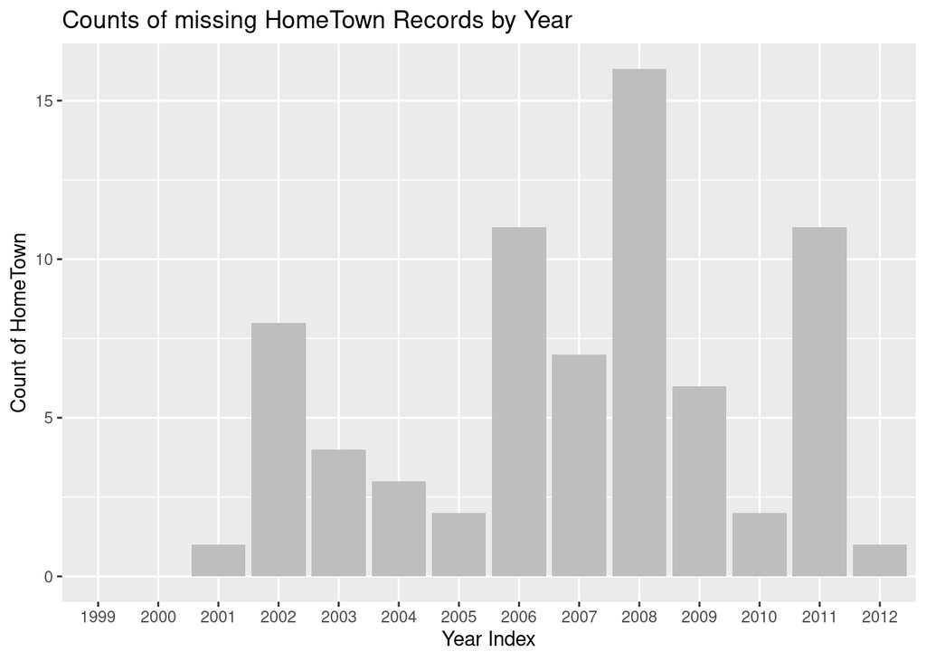

```r
p1_na = ggplot(na_df, aes(x=year_idx, y=HomeTown)) + geom_bar(stat = "identity", fill = "grey") + labs(title = "Counts of missing HomeTown Records by Year") + xlab("Year Index") + ylab("Count of HomeTown")
p1_na
```

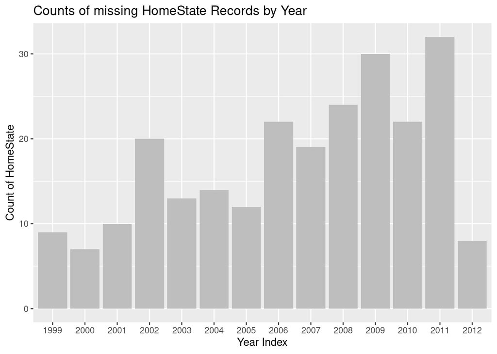

```r
p2_na = ggplot(na_df, aes(x=year_idx, y=HomeState)) + geom_bar(stat = "identity", fill = "grey") +  labs(title = "Counts of missing HomeState Records by Year") + xlab("Year Index") + ylab("Count of HomeState")

p2_na
```

## We will remove NAs and only focus on completed records and rewmove NAs for further processing and reindex the table.

```r
womens_table_T = womens_table_T[complete.cases(womens_table_T), ]
row.names(womens_table_T) = NULL
```

### Final dataframe metadata

```r
head(womens_table_T, n = 10)
```

```
##    Age year      HomeTown HomeState HomeCountry RawTime_S RawTime_M RawPace_S
## 1   27 1999       CONCORD        MA         USA      3339  55.65000       334
## 2   30 1999        EUGENE        OR         USA      3373  56.21667       337
## 3   37 1999   BLOOMINGTON        MN         USA      3443  57.38333       344
## 4   39 1999   ALBUQUERQUE        NM         USA      3444  57.40000       344
## 5   32 1999   CHAPEL HILL        NC         USA      3471  57.85000       347
## 6   30 1999    WASHINGTON        DC         USA      3485  58.08333       349
## 7   31 1999      COLUMBIA        MD         USA      3516  58.60000       352
## 8   25 1999    ALEXANDRIA        VA         USA      3582  59.70000       358
## 9   38 1999 SILVER SPRING        MD         USA      3588  59.80000       359
## 10  31 1999     ROCKVILLE        MD         USA      3630  60.50000       363
##    RawPace_M sex section PiS  TiS PiD TiD
## 1   5.566667   W     10M   9 2358   4 559
## 2   5.616667   W     10M  11 2358   2 529
## 3   5.733333   W     10M  12 2358   2 387
## 4   5.733333   W     10M  13 2358   3 387
## 5   5.783333   W     10M  14 2358   3 529
## 6   5.816667   W     10M  15 2358   4 529
## 7   5.866667   W     10M  16 2358   5 529
## 8   5.966667   W     10M  18 2358   5 559
## 9   5.983333   W     10M  19 2358   4 387
## 10  6.050000   W     10M  20 2358   6 529
```

```r
Descriptions = c('Participant Age', 'Year of race', 'Participant Home Town', 'Participant Home State', 'Participant Home Country', "Participant's Time in Seconds", "Participant's Time in Minutes", "Participants Mile Pace in Seconds", "Participants Mile Pace in Minutes", "Gender", "Participant Race", "Position in Sex", "Total in Sex", "Position in Division", "Total in Division")
womensTableInfo = data.frame(Feature = names(womens_table_T), Description = Descriptions , Type = sapply(womens_table_T, typeof), row.names = NULL)
womensTableInfo
```

```
##        Feature                       Description      Type
## 1          Age                   Participant Age    double
## 2         year                      Year of race   integer
## 3     HomeTown             Participant Home Town character
## 4    HomeState            Participant Home State character
## 5  HomeCountry          Participant Home Country character
## 6    RawTime_S     Participant's Time in Seconds    double
## 7    RawTime_M     Participant's Time in Minutes    double
## 8    RawPace_S Participants Mile Pace in Seconds    double
## 9    RawPace_M Participants Mile Pace in Minutes    double
## 10         sex                            Gender character
## 11     section                  Participant Race character
## 12         PiS                   Position in Sex character
## 13         TiS                      Total in Sex character
## 14         PiD              Position in Division character
## 15         TiD                 Total in Division character
```

### Generate plots of quick EDA for ages accross years

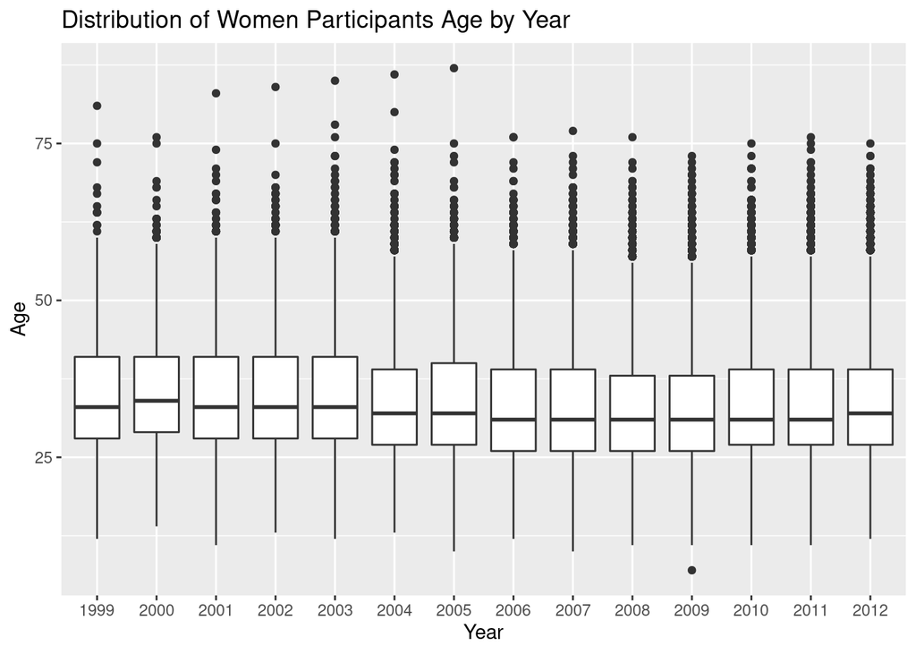

```r
plot_data_age = ggplot(womens_table_T, aes(x = year, y = Age)) + geom_boxplot() + labs(title = "Distribution of Women Participants Age by Year") + xlab("Year") + ylab("Age")

plot_data_age
```

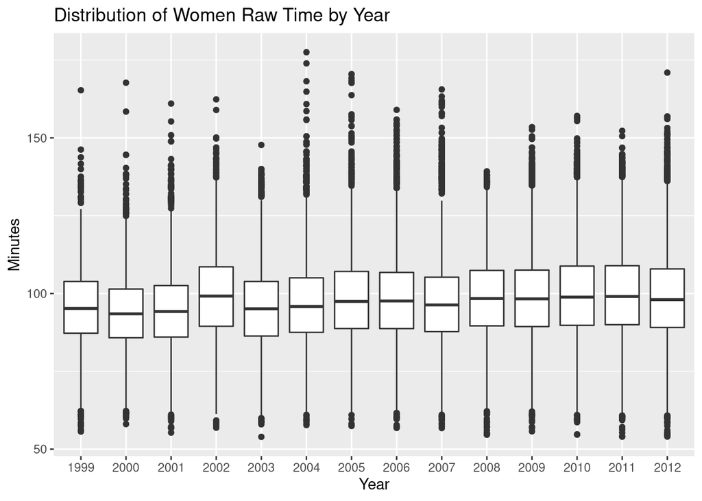

```r
plot_data_time = ggplot(womens_table_T, aes(x = year, y = RawTime_M)) + geom_boxplot() + labs(title = "Distribution of Women Raw Time by Year") + xlab("Year") + ylab("Minutes")

plot_data_time
```

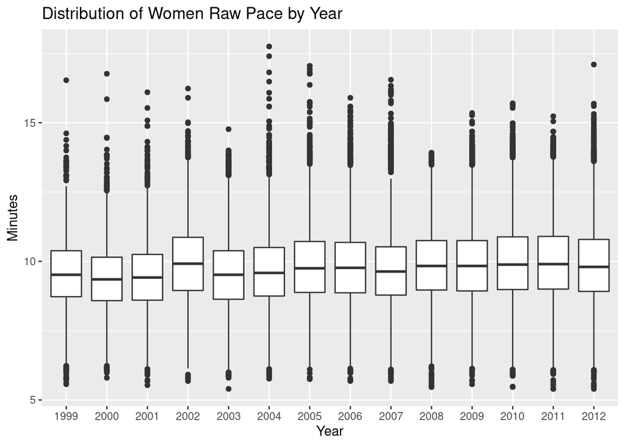

```r
plot_data_Pace = ggplot(womens_table_T, aes(x = year, y = RawPace_M)) + geom_boxplot() + labs(title = "Distribution of Women Raw Pace by Year") + xlab("Year") + ylab("Minutes")


plot_data_Pace
```

BRIAN GAITHER ############################################################################################################################################################################# #############################################################################################################################################################################

Creating an age bin column for analysis

```r
womens_table_T$AgeBin = cut(womens_table_T$Age, breaks=c(0,5,15,25,35,45,55,65,75,85,95),labels=c("1-5","6-15","16-25","26-35","36-45","46-55","56-65","66-75","76-85","86-95"))
```

Creating a column to bin the pace in minutes for later analysis

```r
womens_table_T$PaceBin = cut(womens_table_T$RawPace_M, breaks=c(0,5,5.5,6,6.5,7,7.5,8,8.5,9,9.5,10,10.5,11,11.5,12,12.5,13,13.5,14,18),
                 labels=c("1-5","5.1-5.5","5.5-6","6-6.5","6.5-7","7-7.5","7.5-8","8-8.5","8.5-9","9-9.5","9.5-10","10-10.5","10.5-11","11-11.5","11.5-12","12-12.5","12.5-13","13-13.5","13.5-14","11-18"))
```

write out the dataframe for later retrieval

```r
#write.csv(womens_table_T,"C:/Users/blgai/OneDrive/Documents/School/SMU/Spring 2021/Quantifying the World/Case4/files/women_data.csv", row.names = FALSE)
```

read the data into dataframe

```r
#womens_table_T = read.csv("C:/Users/blgai/OneDrive/Documents/School/SMU/Spring 2021/Quantifying the World/Case4/files/women_data.csv", header=TRUE)
```

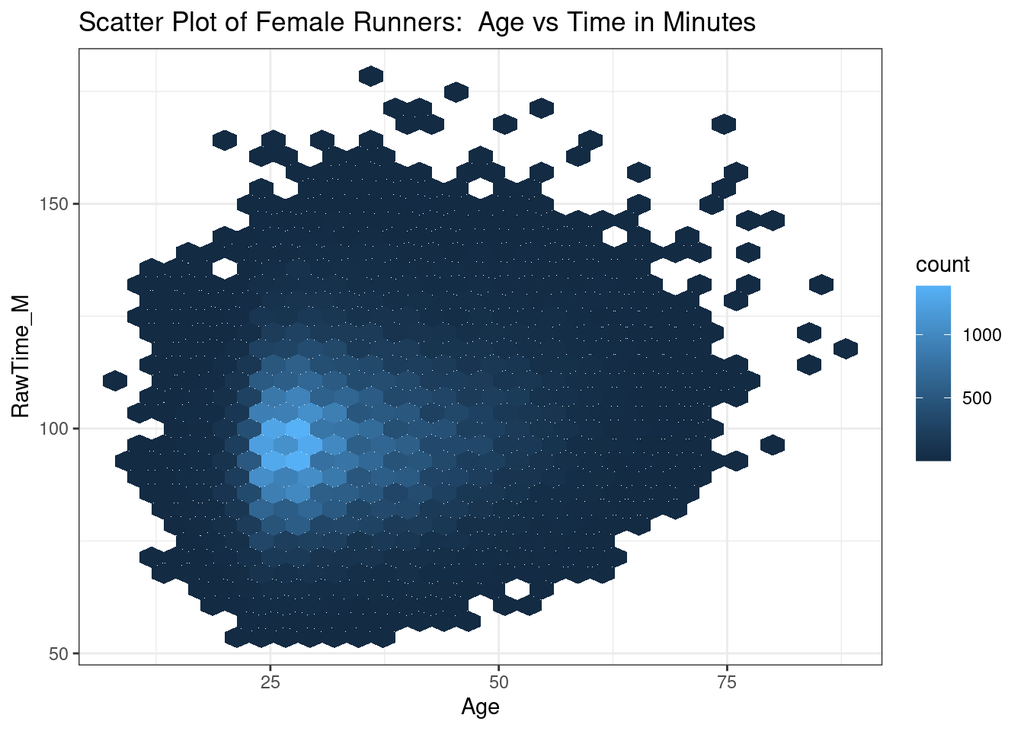

```r
ggplot(womens_table_T, aes(x = Age, y=RawTime_M)) +
  geom_hex() +
  theme_bw() +
  labs(title="Scatter Plot of Female Runners:  Age vs Time in Minutes")
```

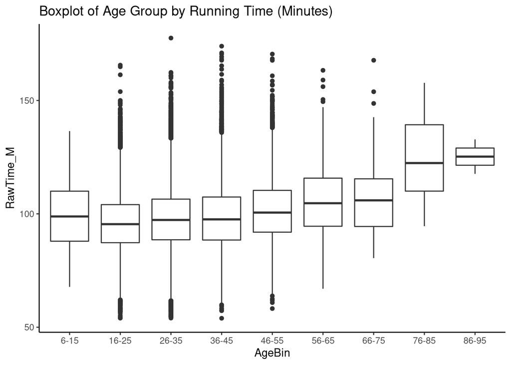

```r
f = ggplot(womens_table_T)
f + geom_boxplot(mapping = aes(x=AgeBin, y=RawTime_M)) + theme_classic() + labs(title="Boxplot of Age Group by Running Time (Minutes)")
```

Let’s examine overall runner volume

```r
dfRunVol = womens_table_T %>% group_by(year) %>% tally()
dfRunVol$year = as.integer(dfRunVol$year)
names(dfRunVol)[2] <- "RunnerVolume"
head(dfRunVol)
```

```
## # A tibble: 6 x 2
##    year RunnerVolume
##   <int>        <int>
## 1     1         2347
## 2     2         2159
## 3     3         2961
## 4     4         3310
## 5     5         3513
## 6     6         3870
```

Plotting out volume of runners by year

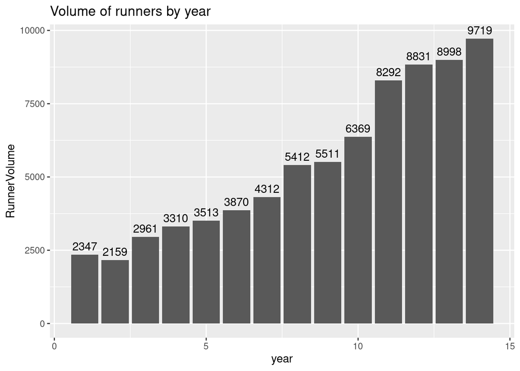

```r
ggplot(dfRunVol, aes(x=year, y=RunnerVolume)) +
  geom_col() +
  labs(title="Volume of runners by year") +
geom_text(aes(label = RunnerVolume), vjust = -0.5)
```

let’s see how well we can predict the volume of racers in the 15th year

```r
lmRunVol = lm(RunnerVolume ~ year, data = dfRunVol)
lmRunVol$coefficients
```

```
## (Intercept)        year
##    800.1978    613.3451
```

Below we see we have a statistically significant slope and intercept

```r
summary(lmRunVol)
```

```
##
## Call:
## lm(formula = RunnerVolume ~ year, data = dfRunVol)
##
## Residuals:
##     Min      1Q  Median      3Q     Max
## -809.30 -511.97   94.27  329.17  933.46
##
## Coefficients:
##             Estimate Std. Error t value Pr(>|t|)
## (Intercept)   800.20     339.09    2.36   0.0361 *
## year          613.35      39.82   15.40 2.87e-09 ***
## ---
## Signif. codes:  0 '***' 0.001 '**' 0.01 '*' 0.05 '.' 0.1 ' ' 1
##
## Residual standard error: 600.7 on 12 degrees of freedom
## Multiple R-squared:  0.9518, Adjusted R-squared:  0.9478
## F-statistic: 237.2 on 1 and 12 DF,  p-value: 2.872e-09
```

See how well our line fits

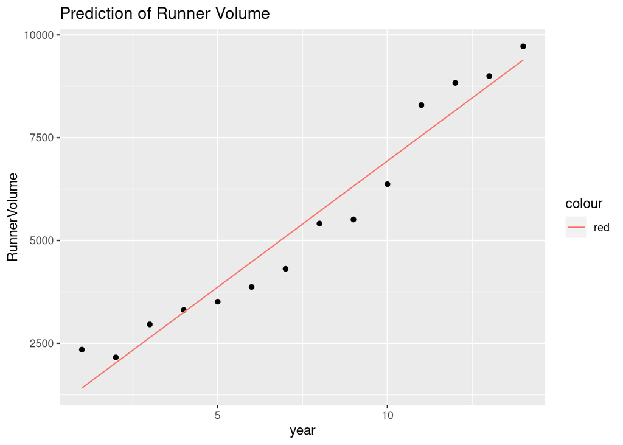

```r
preds = predict(lmRunVol)
ggplot(dfRunVol, aes(x=year, y=RunnerVolume)) + geom_point() + geom_line(dfRunVol, mapping = aes(x=year, y=preds, col = "red")) + ggtitle("Prediction of Runner Volume")
```

How many runners are predicted to attend in 2013 (year 15)

```r
y_hat = 800.5 + (15*613.4)

print(paste0("Predicted volume of runners in 2013 is: ", y_hat))
```

```
## [1] "Predicted volume of runners in 2013 is: 10001.5"
```

95% confidence intervals

```r
dfNew = data.frame(year=15)
predict(lmRunVol, newdata = dfNew, interval = 'confidence')
```

```
##        fit      lwr      upr
## 1 10000.37 9261.564 10739.18
```

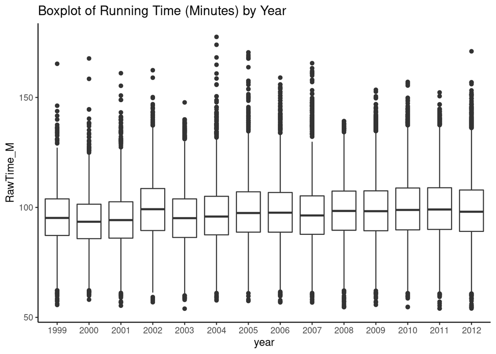

```r
f = ggplot(womens_table_T)
f + geom_boxplot(mapping = aes(x=year, y=RawTime_M)) + theme_classic() + labs(title="Boxplot of Running Time (Minutes) by Year")
```

Let’s look at the volume of runners by pace bin. We can see that the majority of runners are between 8-11 minute pace. This means that a large swell of runners will be running through the course together and race support must have enough volunteers to support the increase of runners as they make their way through the course.

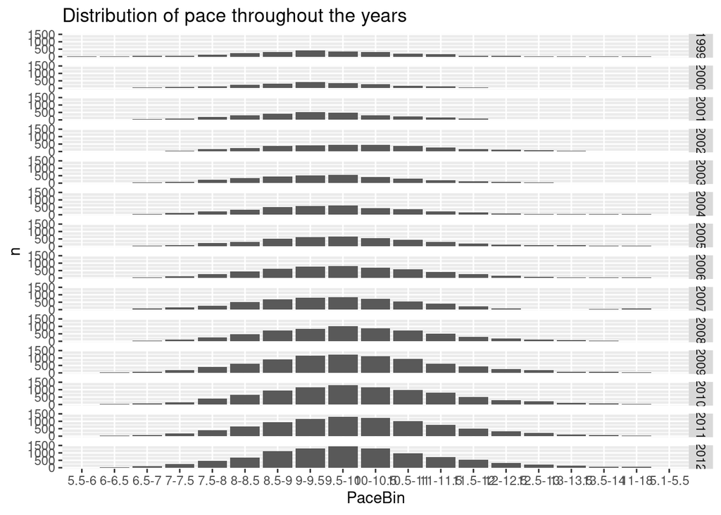

```r
womens_table_T$PaceBin <- as.character(womens_table_T$PaceBin)
womens_table_T$PaceBin <- factor(womens_table_T$PaceBin, levels=unique(womens_table_T$PaceBin))

ggplot(womens_table_T %>% group_by(year, PaceBin) %>% tally()) +
  geom_col(mapping = aes(x=PaceBin, y=n)) +
  facet_grid(vars(year)) +
  labs(title="Distribution of pace throughout the years")
```

Let’s take a look at the median pace per year.

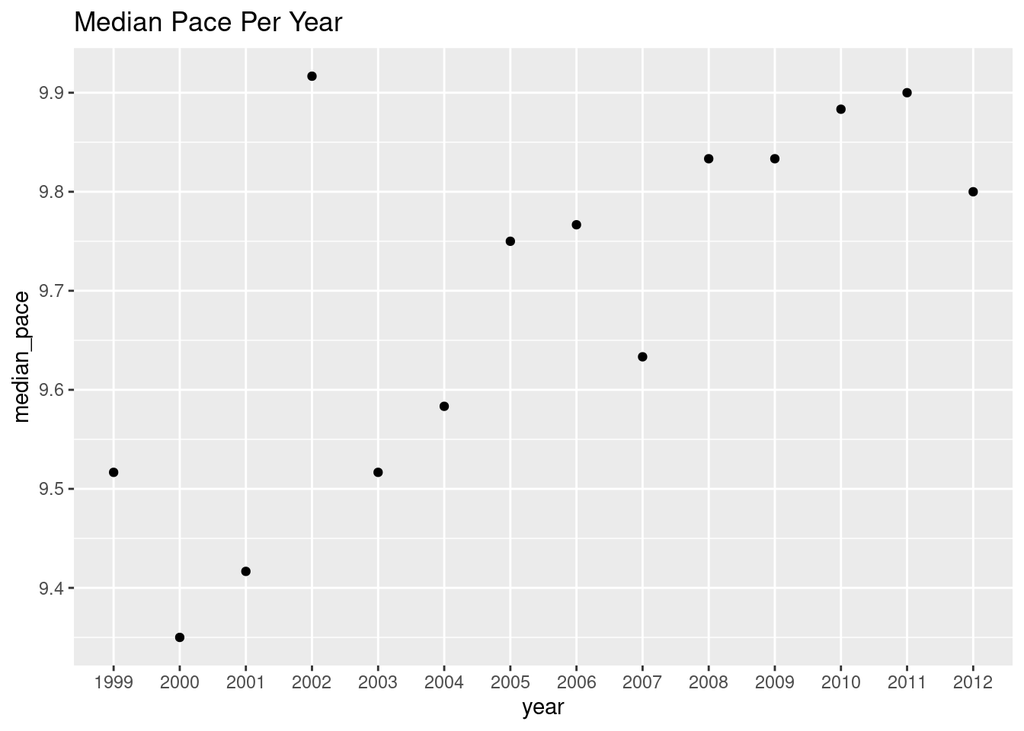

```r
womens_table_T %>% group_by(year) %>% dplyr::summarise(median_pace = median(RawPace_M)) %>% ggplot(aes(x=year, y=median_pace)) + geom_point() + ggtitle("Median Pace Per Year")
```

If we look at the max times throughout the years, there isn’t a consistent pattern observable, we’ll revisit this after looking more at the age bins further

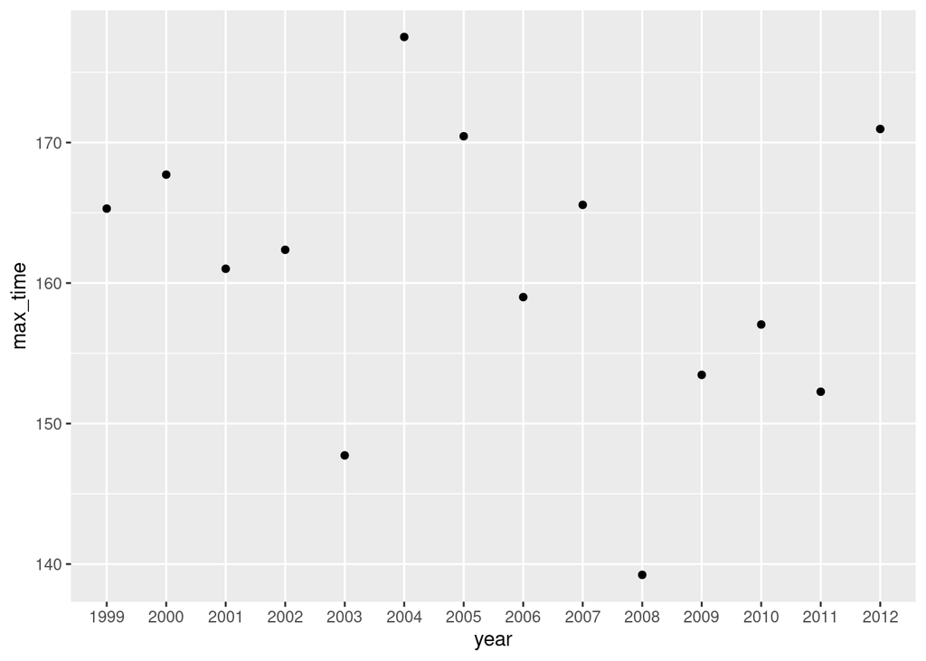

```r
womens_table_T %>% group_by(year) %>% dplyr::summarise(max_time = max( RawTime_M )) %>% ggplot(aes(x=year, y=max_time)) + geom_point()
```

we see below that there has been a steady increase in 26-35 year old runners over the years

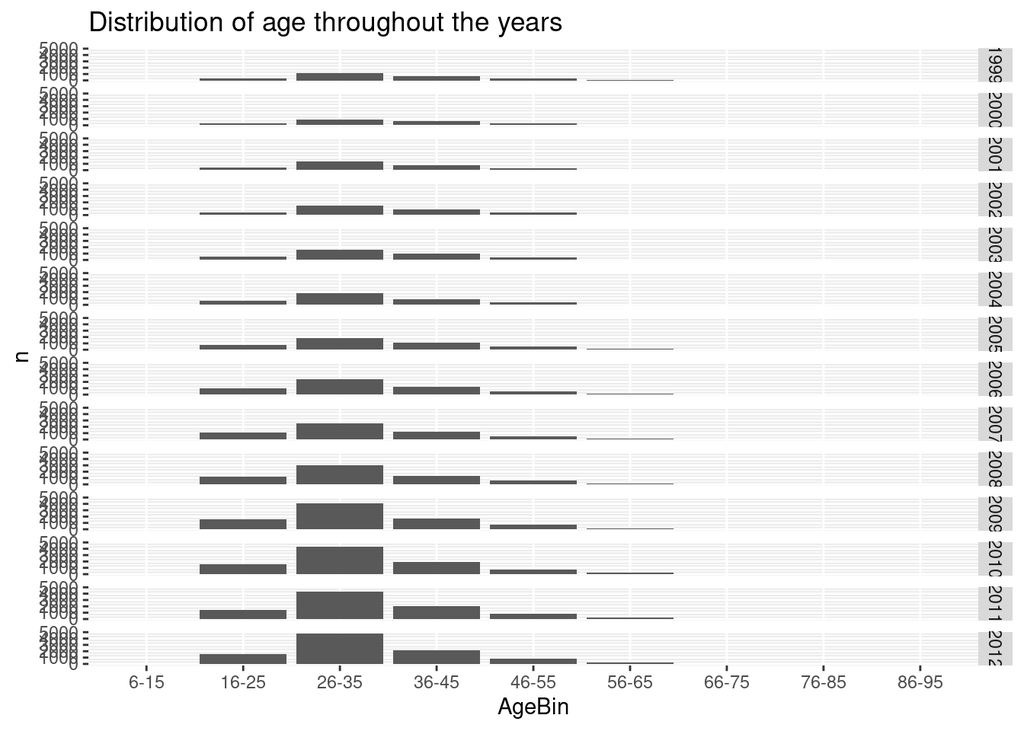

```r
ggplot(womens_table_T %>% group_by(year, AgeBin) %>% tally()) +
  geom_col(mapping = aes(x=AgeBin, y=n)) +
  facet_grid(vars(year)) +
  labs(title="Distribution of age throughout the years")
```

Let’s take a closer look at the volume of runners in the 26-35 age category

```r
dfRunAgeBinVol = womens_table_T %>% group_by(year, AgeBin) %>% dplyr::summarise(AgeBinVolume = n())
head(dfRunAgeBinVol)
```

```
## # A tibble: 6 x 3
## # Groups:   year [1]
##   year  AgeBin AgeBinVolume
##   <fct> <fct>         <int>
## 1 1999  6-15              5
## 2 1999  16-25           286
## 3 1999  26-35          1086
## 4 1999  36-45           649
## 5 1999  46-55           273
## 6 1999  56-65            43
```

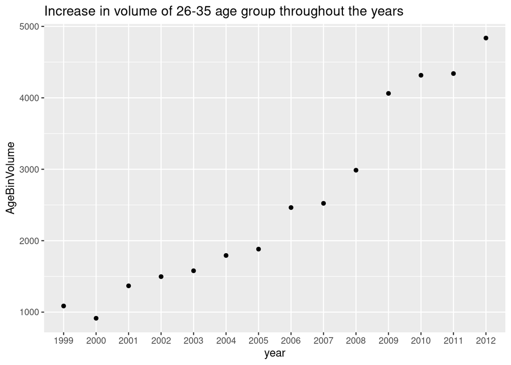

```r
ggplot(dfRunAgeBinVol[dfRunAgeBinVol$AgeBin == '26-35',]) +
  geom_point(mapping = aes(x=year, y=AgeBinVolume)) +
  #facet_wrap(vars(year)) +
  labs(title="Increase in volume of 26-35 age group throughout the years")
```

```r
dfRunAgeBinVol$year = as.numeric(as.character(dfRunAgeBinVol$year))
dfRunAgeBinVol[dfRunAgeBinVol$AgeBin == '26-35',]
```

```
## # A tibble: 14 x 3
## # Groups:   year [14]
##     year AgeBin AgeBinVolume
##    <dbl> <fct>         <int>
##  1  1999 26-35          1086
##  2  2000 26-35           914
##  3  2001 26-35          1368
##  4  2002 26-35          1497
##  5  2003 26-35          1579
##  6  2004 26-35          1793
##  7  2005 26-35          1882
##  8  2006 26-35          2464
##  9  2007 26-35          2523
## 10  2008 26-35          2987
## 11  2009 26-35          4062
## 12  2010 26-35          4316
## 13  2011 26-35          4340
## 14  2012 26-35          4837
```

Let’s trend the volume of 26-35 year old runners using LOESS

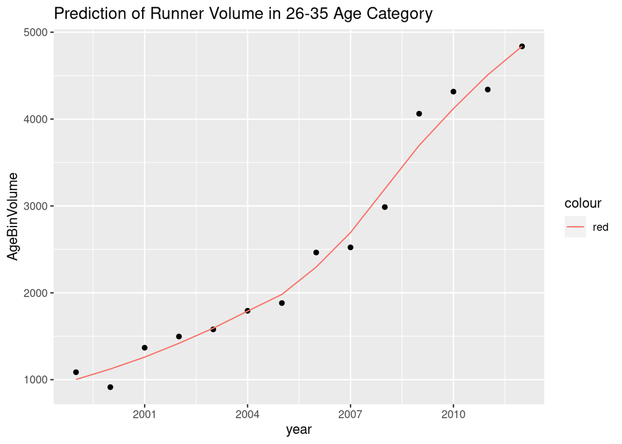

```r
df26 = dfRunAgeBinVol[dfRunAgeBinVol$AgeBin == '26-35',]
loessAge26 = loess(AgeBinVolume ~year, data=df26)
preds = predict(loessAge26)
ggplot(df26, aes(x=year, y=AgeBinVolume)) +
  geom_point() +
  geom_line(df26, mapping = aes(x=year, y=preds, col = "red")) +
  ggtitle("Prediction of Runner Volume in 26-35 Age Category")
```

Let’s now try to predict the volume of 26-35 year olds using a piece wise linear regression model

```r
pw.model = piecewise.linear(df26$year, df26$AgeBinVolume, middle=1, CI=TRUE, sig.level = 0.05)
pw.model
```

```
## [1] "Threshold alpha: 2005.0000564959"
## [1] ""
## [1] "Model coefficients: Beta[0], Beta[1], Beta[2]"
##  (Intercept)            x            w
## -311648.2551     156.3910     276.1541
##       Change.Point Initial.Slope Slope.Change Second.Slope
## 2.5%      2003.562       96.0466     200.5510     388.6335
## 97.5%     2007.560      241.0233     597.8849     702.1710
```

Now that we have a piece wise linear model, let’s predict the volume of 26-35 year olds in years 2013 and 2014

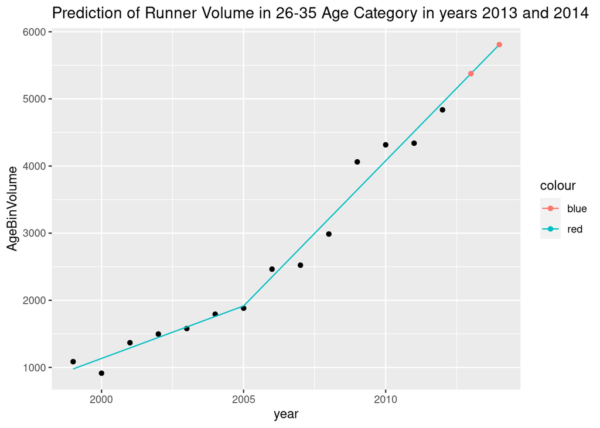

```r
preds = predict(pw.model,c(1999:2014))
predYears = c(1999:2014)
dfPreds = data.frame(year = predYears, predAgeBinVolume = predict(pw.model,predYears))
ggplot(df26, aes(x=year, y=AgeBinVolume)) +
  geom_point() +
  geom_line(dfPreds, mapping = aes(x=year, y=predAgeBinVolume, col = "red")) +
  geom_point(dfPreds[dfPreds$year %in% c(2013:2014), ], mapping = aes(x=year, y=predAgeBinVolume, col = "blue")) +
  ggtitle("Prediction of Runner Volume in 26-35 Age Category in years 2013 and 2014")
```

The actual predicted values for years 2013 and 2014. This is what we want to share with the race management team

```r
predict(pw.model,c(2013:2014))
```

```
## [1] 5376.135 5808.681
```

Let’s look at average times of age 25-36 year olds

```r
dfAvgTimes26 = womens_table_T %>% group_by(year, AgeBin) %>% dplyr::summarise(avgTime = mean(RawTime_M))
```

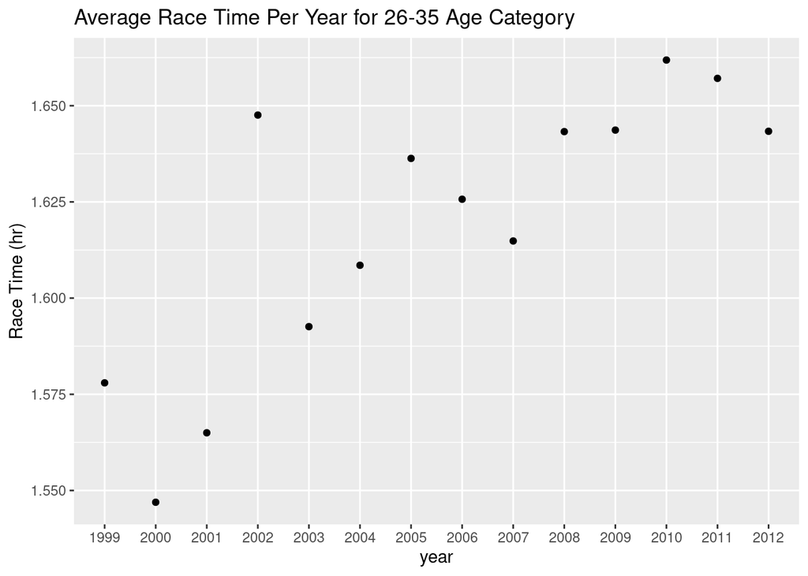

```r
dfAvgTimes26 = dfAvgTimes26[dfAvgTimes26$AgeBin == '26-35',]
dfAvgTimes26 %>% ggplot(aes(x=year, y=avgTime/60)) + geom_point() + ggtitle("Average Race Time Per Year for 26-35 Age Category") + labs(y="Race Time (hr)")
```

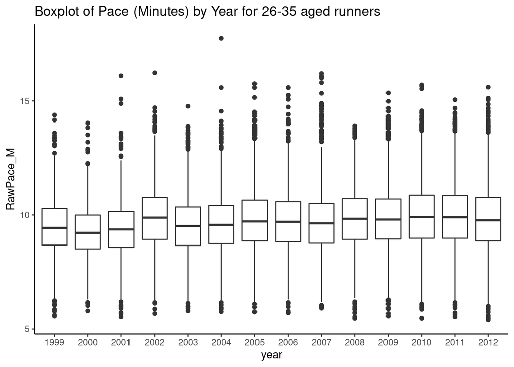

```r
f = ggplot(womens_table_T %>% filter(womens_table_T$AgeBin == "26-35"))
f + geom_boxplot(mapping = aes(x=year, y=RawPace_M)) + theme_classic() + labs(title="Boxplot of Pace (Minutes) by Year for 26-35 aged runners")
```

Let’s look at median times of age 25-36 year olds

```r
dfMedTimes26 = womens_table_T %>% group_by(year, AgeBin) %>% dplyr::summarise(medTime = median(RawTime_M))
```

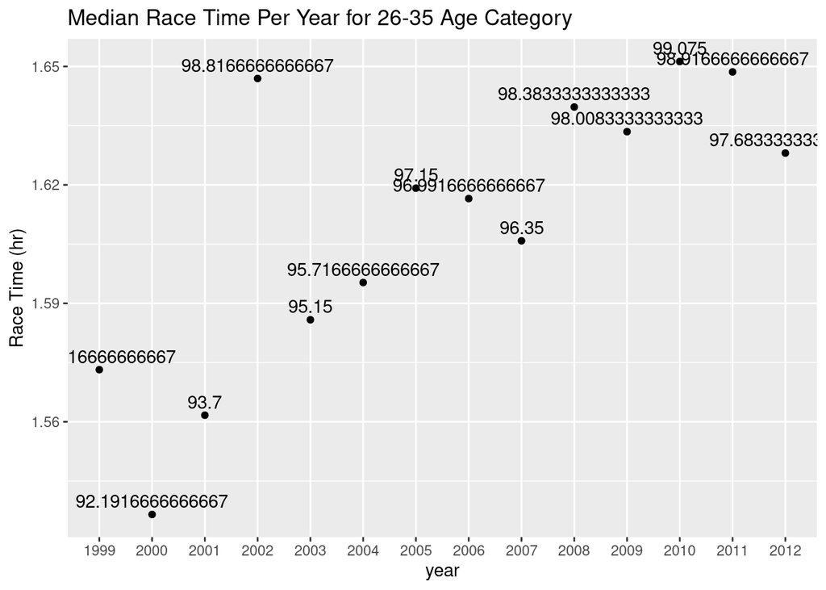

```r
dfMedTimes26 = dfMedTimes26[dfMedTimes26$AgeBin == '26-35',]
dfMedTimes26 %>% ggplot(aes(x=year, y=medTime/60)) + geom_point() + ggtitle("Median Race Time Per Year for 26-35 Age Category") + labs(y="Race Time (hr)")  +
geom_text(aes(label = medTime), vjust = -0.5)
```

Let’s look at the proportion the 26-35 year olds make up of the total runners over the years. As of 2012, this age group makes up about 50% of all runners.

```r
dfAgg = womens_table_T %>% filter(womens_table_T$AgeBin == "26-35") %>% group_by(year, AgeBin) %>% dplyr::summarise(AgeBinVolume = n())
dfAgg$TotalRunners = (womens_table_T %>% group_by(year) %>% dplyr::summarise(TotalRunners = n()))$TotalRunners
```

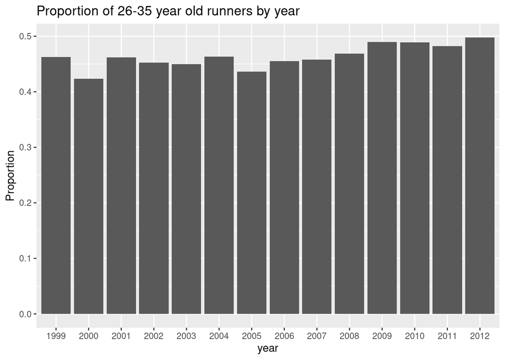

```r
dfAgg$Proportion = dfAgg$AgeBinVolume / dfAgg$TotalRunners

ggplot(dfAgg, aes(x=year, y=Proportion)) +
  geom_col() +
  labs(title="Proportion of 26-35 year old runners by year")
```

So to summarize, it’s expected that 50% of the runners will be in the 26-35 year old age group in 2013. The median race time will be 97-98 minutes or approximately 9.7 minute pace.